# Deterministic and stochastic effects of food quality on extinction time

David Nguyen

2020-12-18

# Data

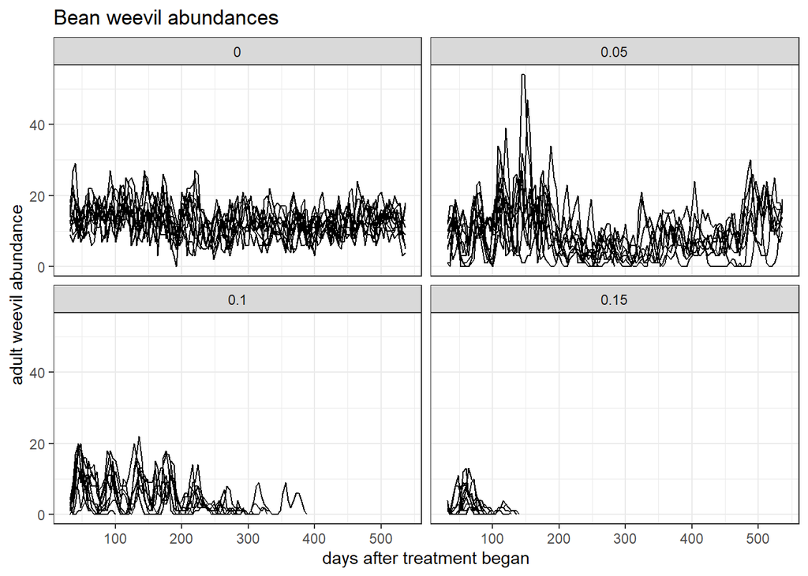

- Response: Census of adult weevils every 4 days
- Treatment: food quality (0, 5, 10 , 15 % peanut shell)
- Experimental design: 10 replicates per treatment level = 40 populationsx
  - Pure bean pellets and 4 adult weevils added every 4 days up to day 28
  - Day 32 treatment begins. Food added every 7 days.

# Model

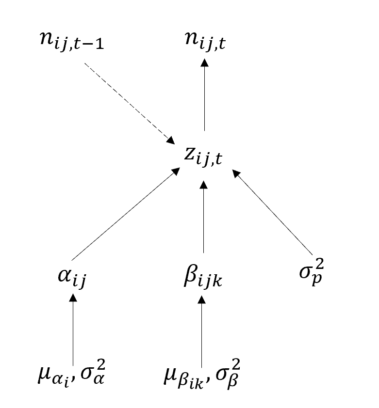

### Definitions

- $n_{ij,t}:$ the adult weevil count for treatment $i$, replicate $j$, and time $t$
- $n_{ij,t-1}:$ the adult weevil count for treatment $i$, replicate $j$, and time $t-1$ lag
- $z_{ij,t}:$ The expected number of adult weevils for treatment $i$, replicate $j$, and time $t$
- $\alpha_{ij}:$ treatment specific population growth rate in replicate $j$
- $\beta_{ij}:$ effect of previous population size at $t-1$ on expected number of adult weevils at time $t$ for treatment $i$ in replicate $j$
- $\mu_{\alpha,i}:$ the mean population growth rate for treatment $i$
- $\mu_{\beta_{i}}:$ the mean effect of previous population size at $t-1$ on expected number of adult weevils at time $t$ for treatment $i$
- $\sigma_{\alpha}^2:$ variance of distribution of population growth rates
- $\sigma_{\beta}^2:$ variance of distribution of density dependence magnitudes (maybe should make it specific to lag $k$?)

### Gompertz process model

$$\begin{align}
N_t & = N_{t-1}\exp(\alpha + \beta\ln(N_{t-1})) \\
& = g(\alpha,\beta, n_{t-1}) \\
\end{align}$$

But, note that when $N_{t-1}=0$, then all subsequent abundances will be zero.

The log-gompertz model (might?) be more useful for estimation since we no longer multiply by $N_{t-1}$.
$$\begin{align}
X_t & = \alpha + \beta X_{t-1}\\
& = g(\alpha,\beta, n_{t-1}) \\
\end{align}$$

Note that $\beta_1$ in the log-gompertz is technically $(1+\beta_1)$ for the model on arithmetic (not-logged) scale.

### Full model

$$\begin{align}
[\boldsymbol{\alpha, \beta, \mu_{\alpha}, \mu_{\beta}},Z, \sigma_{p}^2, \sigma_{\alpha}^2, \sigma_{\beta}^2| \boldsymbol{N}] \propto
\prod_{i=1}^{4} \prod_{j=1}^{J_{ij}} \prod_{t=1}^{T_{ij}}
& \text{Poisson}[n_{ij,t} | \exp(Z_{ij,t})]\\
& \text{normal}(Z_{ij,t} | g(\alpha_{i},\beta_{ik},n_{ij,t-1}, \ldots, n_{ij,t-1}), \sigma_p^2)\\
& \text{N}[\alpha_{ij} | \mu_{\alpha,i}, \sigma_{\alpha}^2] \\
& \text{N}[\beta_{ij} | \mu_{\beta_{i}}, \sigma_{\beta}^2] \\
& \text{Unif}[\mu_{\alpha,i} | 0, 3] \\
& \text{Unif}[\mu_{\beta_{ik}} | -1.1, 1.1] \\
& \text{inv.gamma}[\sigma_{\alpha}^2 | 0.001, 0.001] \\
& \text{inv.gamma}[\sigma_{\beta}^2 | 0.001, 0.001] \\
& \text{inv.gamma}[\sigma_{p}^2 | 0.001, 0.001] \\
\end{align}$$

# Model fitting: Direct density dependence

This is the full model presented earlier with direct density dependence only ($k=1$).

```r
set.seed(123)
data <-
  list(
  n = as.numeric(weevil$N_lag0),
  lag1 = as.numeric(ifelse(weevil$N_lag1 == 0, 0.001, weevil$N_lag1)),
  lnlag1 = log(ifelse(weevil$N_lag1 == 0, 0.001, weevil$N_lag1)),
  replicate = as.numeric(weevil$replicate), # nx1 vector of replicate numbers for each observation
  sreplicate = as.numeric(1:10), # replicate numbers
  treatment = as.numeric(weevil$ftreatment), # nx1 vector of treatment levels for each observation
  streatment = as.numeric(1:4), # treatment levels
  start_index = as.numeric(trt_index$init_index), # 1st obs. number for trt 1:4
  end_index = as.numeric(trt_index$end_index) # last obs. number for trt 1:4
)

inits <-
  list(
    list(mu_a = rep(1, 4), mu_b = rep(0.5, 4), tau_a = 1/5, tau_b = 1/5, tau_p = 0.001),
    list(mu_a = rep(0.5, 4), mu_b = rep(0.2, 4), tau_a = 1/10, tau_b = 1/10, tau_p = 0.01),
    list(mu_a = rep(1.5, 4), mu_b = rep(0.9, 4), tau_a = 1/100, tau_b = 1/100, tau_p = 0.005)
  )

variablenames <- c("mu_a","mu_b", "sd_a","sd_b", "sd_p", "K", #"n_new",
                   "ts_cv", "ts_new_cv", "indicator_cv",
                   "ts_max", "ts_new_max", "indicator_max")
modelstring="
model{
  #likelihood
  for (t in 1:length(n)){
    z[t] ~ dnorm(a[treatment[t], replicate[t]] + b[treatment[t], replicate[t]]*lnlag1[t], tau_p)
    n[t] ~ dpois(exp(z[t]))

    # posterior predictive dist. Uses new values for a and b for each replicate
    z_new[t] ~ dnorm(a_new[treatment[t], replicate[t]] + b_new[treatment[t], replicate[t]]*lnlag1[t], tau_p)
    n_new[t] ~ dpois(exp(z_new[t]))
  }

  # draw a and b's
  # store in a 4 x 10 matrix (rows are treatment levels, cols are replicate number)
  for (i in 1:length(streatment)) {
  for (j in 1:length(sreplicate)) {
      a[i, j] ~ dnorm(mu_a[i], tau_a)
      b[i, j] ~ dnorm(mu_b[i], tau_b)

      # get new a and b for replicates for posterior predictive dist'n
      a_new[i, j] ~ dnorm(mu_a[i], tau_a)
      b_new[i, j] ~ dnorm(mu_b[i], tau_b)
  }
  }
  # Draw for mean of treatment specific a and b
  for (i in 1:length(streatment)) {
      mu_a[i] ~ dunif(0,3)
      mu_b[i] ~ dunif(-1.1, 1.1)
  }

  # Draw for precisions
  tau_a ~ dgamma(0.001, 0.001)
  tau_b ~ dgamma(0.001, 0.001)
  tau_p ~ dgamma(0.001, 0.001) # same process error across treatments

  # convert precision to sd
  sd_a <- 1/sqrt(tau_a)
  sd_b <- 1/sqrt(tau_b)
  sd_p <- 1/sqrt(tau_p)

  # Compute carrying capacity
  for (i in 1:length(streatment)) {
    K[i] <- exp(mu_a[i]/(1-mu_b[i]))
  }

  # compute test statistics for each treatment group
  for (i in 1:length(streatment)) {
    # coefficient of variation
    ts_cv[i] <- mean(n[start_index[i]:end_index[i]]) / sd(n[start_index[i]:end_index[i]])
    ts_new_cv[i] <- mean(n_new[start_index[i]:end_index[i]]) / sd(n_new[start_index[i]:end_index[i]])
    indicator_cv[i] <- ifelse(ts_new_cv[i] > ts_cv[i], 1, 0)

    # Max abundance
    ts_max[i] <- max(n[start_index[i]:end_index[i]])
    ts_new_max[i] <- max(n_new[start_index[i]:end_index[i]])
    indicator_max[i] <- ifelse(ts_new_max[i] > ts_max[i], 1, 0)
  }
}"

jm = jags.model(textConnection(modelstring),data,inits,n.chains=length(inits),n.adapt=1000) #create model in R
update(jm, n.iter=10000) #burn-in
cs = coda.samples(jm,variable.names = variablenames,n.iter=30000) #generate chains
save(cs, file = "chains/weevil_random_trt_proc_error.RData")
```

# Checking convergence

### trace plots

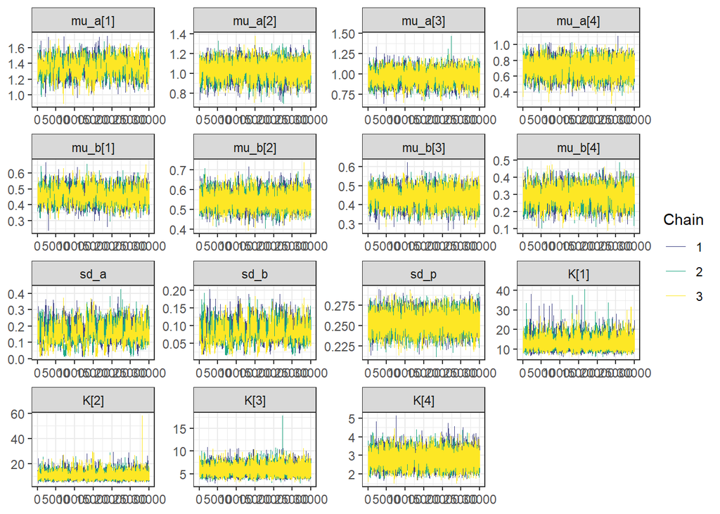

```r
load("chains/weevil_random_trt_proc_error.RData")
color_scheme_set("viridis")
bayesplot::mcmc_trace(cs, pars = vars(starts_with(c("mu", "sd", "K"))))
```

### density plots

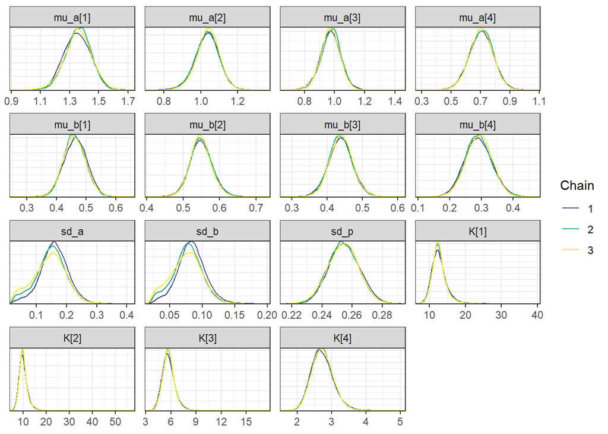

```r
bayesplot::mcmc_dens_overlay(cs, pars = vars(starts_with(c("mu", "sd", "K"))))
```

### autocorrelation of chains

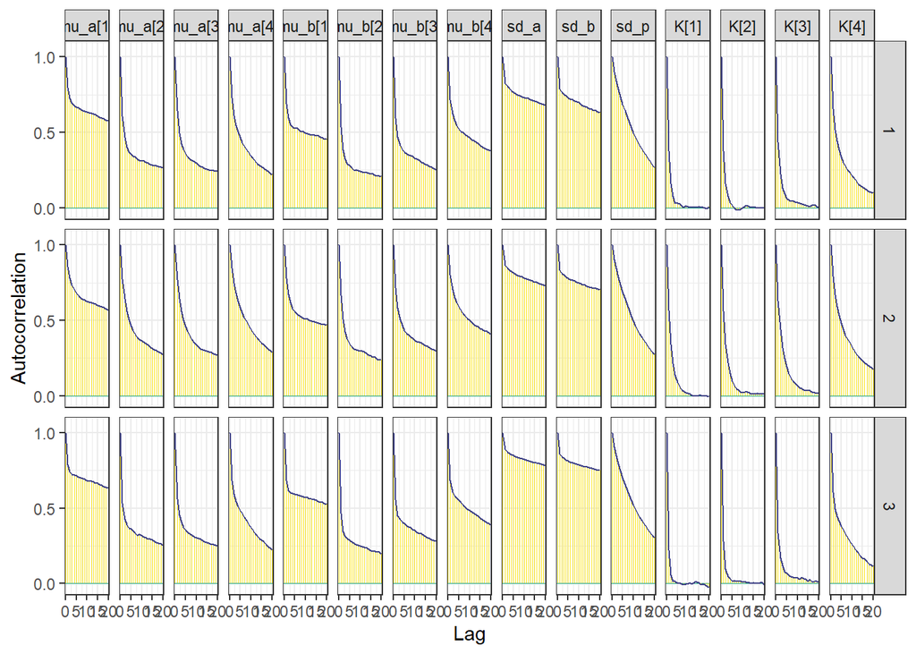

```r
bayesplot::mcmc_acf(cs, pars = vars(starts_with(c("mu", "sd", "K"))))
```

### R-hat and effective sample size

```r
MCMCvis::MCMCsummary(cs, params = c("mu_a","mu_b", "sd_a","sd_b", "sd_p", "K")) %>% knitr::kable(digits = 2)
```

|  | mean | sd | 2.5% | 50% | 97.5% | Rhat | n.eff |
| --- | --- | --- | --- | --- | --- | --- | --- |
| mu_a[1] | 1.36 | 0.09 | 1.18 | 1.36 | 1.53 | 1.00 | 541 |
| mu_a[2] | 1.04 | 0.07 | 0.90 | 1.04 | 1.16 | 1.00 | 2293 |
| mu_a[3] | 0.97 | 0.07 | 0.84 | 0.97 | 1.10 | 1.00 | 2383 |
| mu_a[4] | 0.71 | 0.08 | 0.54 | 0.71 | 0.86 | 1.00 | 3449 |
| mu_b[1] | 0.46 | 0.04 | 0.39 | 0.46 | 0.54 | 1.00 | 734 |
| mu_b[2] | 0.55 | 0.03 | 0.49 | 0.55 | 0.61 | 1.00 | 3205 |
| mu_b[3] | 0.44 | 0.03 | 0.37 | 0.44 | 0.51 | 1.00 | 2076 |
| mu_b[4] | 0.29 | 0.04 | 0.21 | 0.29 | 0.38 | 1.00 | 1496 |
| sd_a | 0.15 | 0.05 | 0.04 | 0.15 | 0.25 | 1.01 | 313 |
| sd_b | 0.08 | 0.02 | 0.03 | 0.08 | 0.12 | 1.01 | 353 |
| sd_p | 0.25 | 0.01 | 0.23 | 0.25 | 0.27 | 1.00 | 3038 |
| K[1] | 12.69 | 2.10 | 9.29 | 12.45 | 17.63 | 1.00 | 39381 |
| K[2] | 10.17 | 1.92 | 7.12 | 9.94 | 14.68 | 1.00 | 33446 |
| K[3] | 5.73 | 0.76 | 4.39 | 5.68 | 7.43 | 1.00 | 22130 |
| K[4] | 2.73 | 0.32 | 2.15 | 2.72 | 3.41 | 1.00 | 5934 |

```r
#lapply(cs, coda::effectiveSize) %>% dplyr::bind_rows() #%>% summarise_all(funs(sum))# can also comput n.eff like this
```

- $\hat R:$ measures ratio average variance within change compared to across chains.
- Effective sample size: measures how much autocorrelation in chains increases uncertainty in estimates of posterior
  - how large does my $N_{eff}$ need to be? Not sure - see mcmcse

### Model Checking

Coefficient of variation: $CV_i = \mu_i/\sigma_i$

Posterior predictive check: coefficient of variation

| treatment | ts_obs | ts_pred | p_value |
| --- | --- | --- | --- |
| 0.00 | 2.9644458 | 2.055061 | 0.0000000 |
| 0.05 | 1.3182378 | 1.411516 | 0.8322889 |
| 0.10 | 1.0066157 | 1.180144 | 0.9872111 |
| 0.15 | 0.8217851 | 1.061684 | 0.9994667 |

Maximum: $\text{max}(\boldsymbol{n_i})$

Posterior predictive check: max abundance

| treatment | ts_obs | ts_pred | p_value |
| --- | --- | --- | --- |
| 0.00 | 29 | 48.06102 | 0.9974333 |
| 0.05 | 54 | 48.79607 | 0.2485556 |
| 0.10 | 22 | 24.34962 | 0.5663444 |
| 0.15 | 13 | 10.50621 | 0.0916111 |

# Comparing models

$X_{ij,t} = a_i + b_i X_{ij,t-1}+N(0,\sigma_i^2)$, for treatment $i = 1,2,3,4$, replicate $j = 1,\ldots,10$.

- Both
  - Gompertz with direct density dependence
- Bayesian
  - response is poisson with lognormal process error
  - random effect of treatment (variation among replicates)
  - shared parameters: $\sigma_a, \sigma_b, \sigma_p$
- GLS
  - response is lognormal
  - fixed effect of treatments (no random effect of replicate)
  - treatment specific residual (process error)

### Parameter estimates

Parameter estimates from hierarchical bayes model

| treatment | density dependence (b) | population growth rate (a) | process noise (sd) |
| --- | --- | --- | --- |
| 0 | 0.46 ( 0.39 , 0.54 ) | 1.36 ( 1.18 , 1.53 ) | 0.25 ( 0.23 , 0.27 ) |
| 0.05 | 0.55 ( 0.49 , 0.61 ) | 1.04 ( 0.9 , 1.16 ) | 0.25 ( 0.23 , 0.27 ) |
| 0.1 | 0.44 ( 0.37 , 0.51 ) | 0.97 ( 0.84 , 1.1 ) | 0.25 ( 0.23 , 0.27 ) |
| 0.15 | 0.29 ( 0.21 , 0.38 ) | 0.71 ( 0.54 , 0.86 ) | 0.25 ( 0.23 , 0.27 ) |

Parameter estimates from previous model: treatment specific variance

| treatment | density dependence (b) | population growth rate (a) | process noise (sd) |
| --- | --- | --- | --- |
| 0 | 0.57 ( 0.52 , 0.61 ) | 1.11 ( 0.99 , 1.23 ) | 0.29 ( 0.27 , 0.3 ) |
| 0.05 | 0.25 ( 0.19 , 0.31 ) | 0.38 ( 0.3 , 0.45 ) | 0.48 ( 0.44 , 0.53 ) |
| 0.1 | 0.24 ( 0.17 , 0.31 ) | 0.24 ( 0.16 , 0.32 ) | 0.55 ( 0.49 , 0.61 ) |
| 0.15 | 0.13 ( 0.03 , 0.23 ) | 0.2 ( 0.08 , 0.32 ) | 0.52 ( 0.45 , 0.6 ) |

### Comparison of model predictions

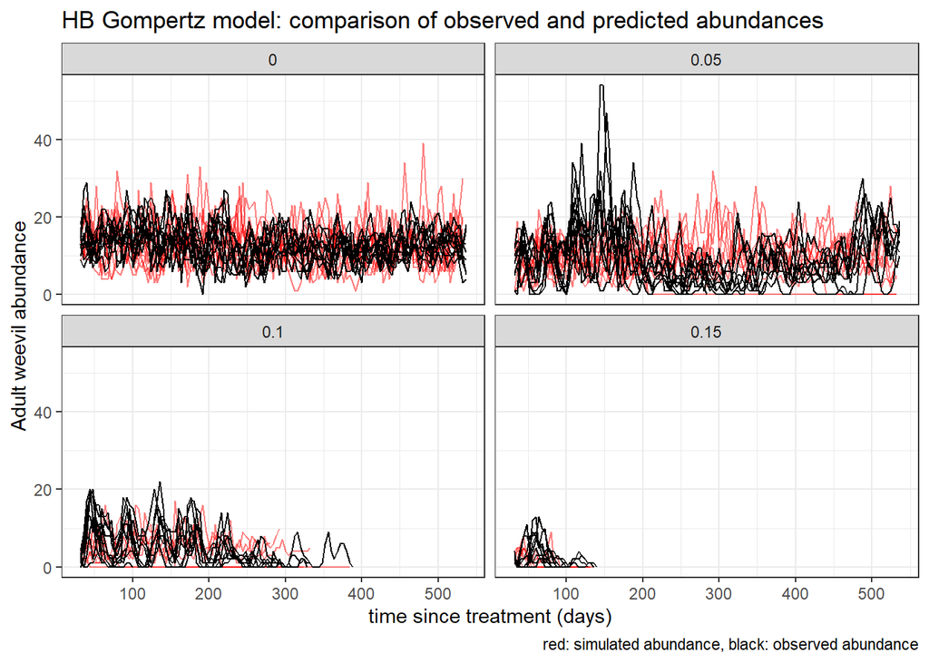

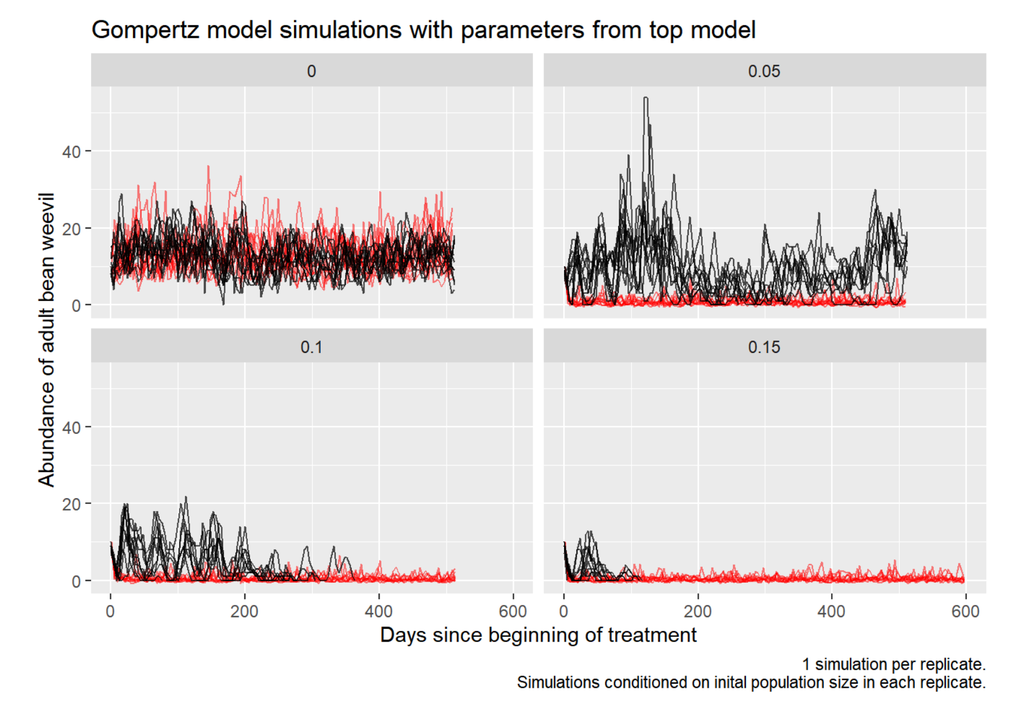

Log-Gompertz model estimated by GLS

# 95% CrI of carrying capacity (derived quantity)

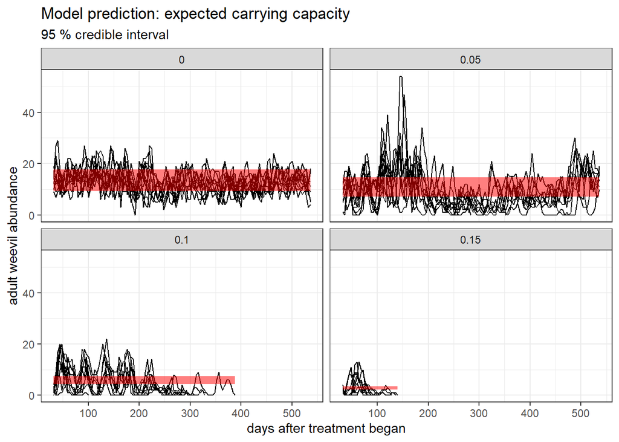

# Predictions for individual replicates

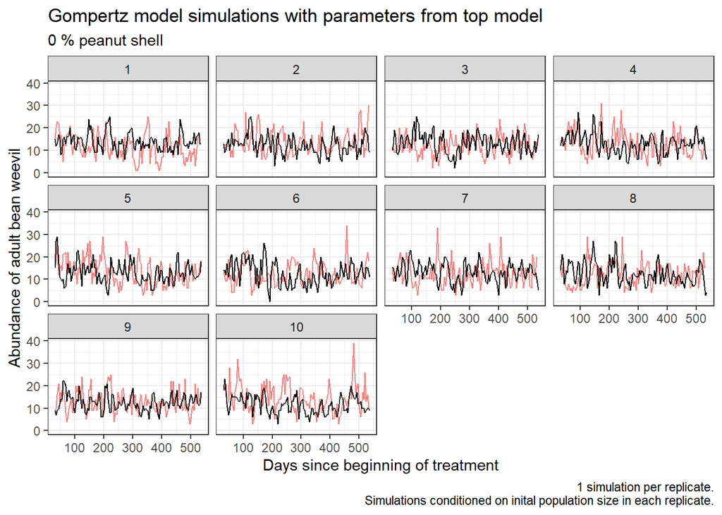

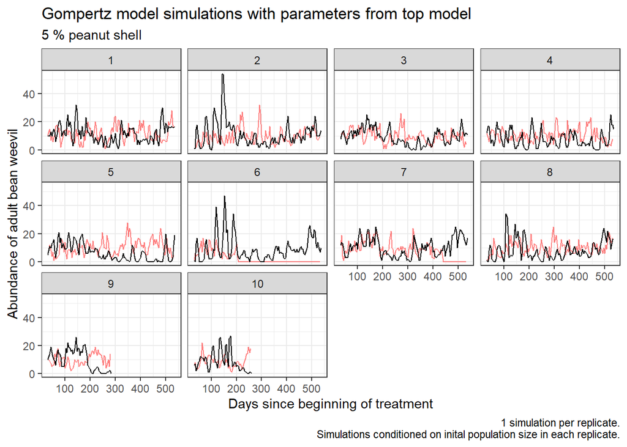

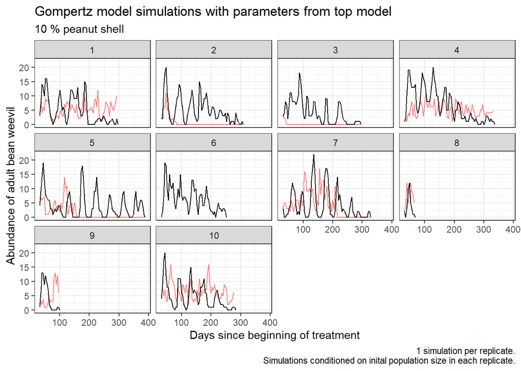

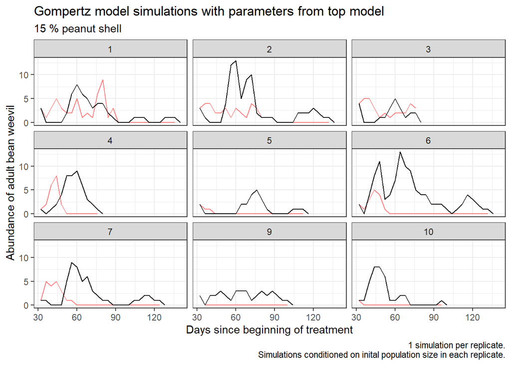

# Final thoughts

- Modeling populations as discrete vs continuous
- Delayed density dependence
- Latent stages
- Look into effective sample size and monte carlo error